# Background maps in R

### Further modifications

ggplot2 has customisable themes. To make a map in a new style, we can first specify the theme that we want. Say you want a theme with no axes, just like the `sp::plot` function:

[figure not shown]

```r
theme_spmap <- theme(panel.background = element_rect(fill = "lightgreen"))
theme_spmap <- theme(axis.line = element_blank(), axis.ticks = element_blank(),
    axis.title.x = element_blank(), axis.title.y = element_blank(), axis.text.y = element_blank(),
    axis.text.x = element_blank(), axis.text.y = element_blank(), axis.text.y = element_blank(),
    panel.background = element_rect(fill = "lightgreen")  # add a light green background, for fun
)
q2 + theme_spmap
```

### Basemaps

```
## converting bounding box to center/zoom specification. (experimental)
## Google Maps API Terms of Service : http://developers.google.com/maps/terms
```

[figure not shown]

```r
library(ggmap)  # you may have to use install.packages to install it first
b <- bbox(lnd)
(lnd.b1 <- ggmap(get_map(location = b)))  # download map data for the lnd data and plot
```

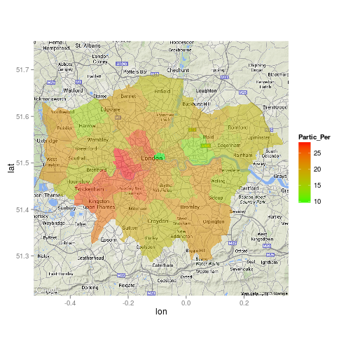

```r
lnd.b1 + geom_polygon(data = lnd.f, aes(x = long, y = lat, group = group, fill = Partic_Per),
    alpha = 0.5) + scale_fill_continuous(low = "green", high = "red")  # add interesting scale
```

This is is getting better, but note that the map is square whilst the data is more rectangular. To do more things with the base map, we need to use a different source.

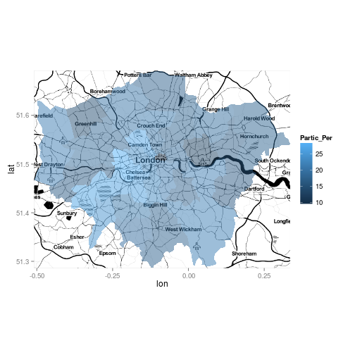

```r
lnd.b2 <- ggmap(get_map(location = b, source = "stamen", maptype = "toner",
    crop = T))
lnd.b2 + geom_polygon(data = lnd.f, aes(x = long, y = lat, group = group, fill = Partic_Per),
    alpha = 0.5)
```

To increase the resolution of the map, we use the zoom command. The `stamen` source can create multiple tiles; the standard Google maps source cannot

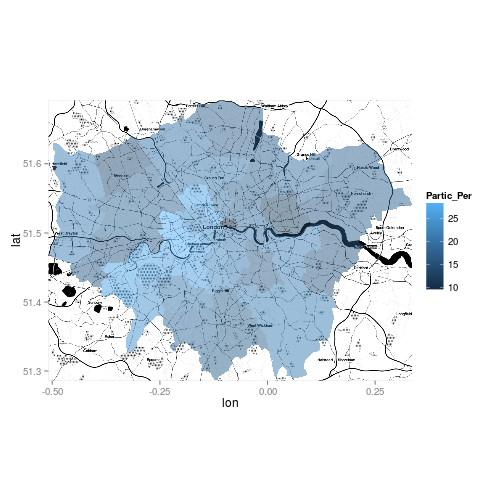

```r
lnd.b3 <- ggmap(get_map(location = b, source = "stamen", maptype = "toner",
    crop = T, zoom = 11))
lnd.b3 + geom_polygon(data = lnd.f, aes(x = long, y = lat, group = group, fill = Partic_Per),
    alpha = 0.5)
```